# 04 Caret Multi-Class Classification

Gary Hutson - Head of Solutions and AI

08/06/2020

## Load data and inspect classification levels

Multi class classification relates to when you dependent variable (predicted variable) has more than two levels. The example we use for this is different readmission bandings.

```r
df <- read.csv("Data/Multiclass_data.csv", header = TRUE)
head(df, 10)
```

```
##    Readmissions.previously High.Risk.Mediciation Mean.LOS.per.readmit.mins
## 1                        2                     0                       220
## 2                        2                     0                       146
## 3                        2                     1                       122
## 4                        2                     0                       123
## 5                        2                     1                       146
## 6                        4                     1                       170
## 7                        3                     1                       109
## 8                        2                     0                        67
## 9                        2                     1                       178
## 10                       1                     0                        68
##    Barratric.patient Patient.Age               Outcome
## 1                  1          81 Readmitted in 30 days
## 2                  1          41 Readmitted in 30 days
## 3                  1          45 Readmitted in 30 days
## 4                  0          80 Readmitted in 30 days
## 5                  0          74 Readmitted in 30 days
## 6                  0          82 Readmitted in 30 days
## 7                  0          86 Readmitted in 30 days
## 8                  0          77 Readmitted in 30 days
## 9                  0          49 Readmitted in 30 days
## 10                 1          44 Readmitted in 30 days
```

```r
table(df$Outcome)
```

```
##
##            Not Readmission      Readmitted in 30 days
##                        150                        150
## Readmitted in last 14 days
##                        150
```

```r
df$Outcome <- make.names(df$Outcome)
df$Outcome <- as.factor(df$Outcome)
levels(df$Outcome)
```

```
## [1] "Not.Readmission"            "Readmitted.in.30.days"
## [3] "Readmitted.in.last.14.days"
```

Again, this is a test dataset and you might have to undertake some type of over or under sampling to get better representation for each of the class labels.

## Create test / train split on dataset

I will create a simple partition on the data to examine the class accuracy using a confusion matrix:

```r
split_idx <- caret::createDataPartition(df$Outcome,
                                        p = 0.8,
                                        list = FALSE)

validation <- df[-split_idx,]
train <- df
```

## Summarise class distribution and dataset

I have created a proportional table function to summarise by the number of classes passed to the table. This will allow you to visualise class membership and proportional distribution:

```r
dim(df)
```

```
## [1] 450   6
```

```r
sapply(df, class)
```

```
##   Readmissions.previously     High.Risk.Mediciation Mean.LOS.per.readmit.mins
##                 "integer"                 "integer"                 "integer"
##         Barratric.patient               Patient.Age                   Outcome
##                 "integer"                 "integer"                  "factor"
```

```r
# Summarise class distribution
class_distribution <- function(field){
  per_dist <- prop.table(table(field)) * 100
  cbind(Class_Frequency=table(field),
        Class_percentage = per_dist) %>%
    as.data.frame()
}

class_distribution(df$Outcome)
```

```
##                            Class_Frequency Class_percentage
## Not.Readmission                        150         33.33333
## Readmitted.in.30.days                  150         33.33333
## Readmitted.in.last.14.days             150         33.33333
```

## Set up resampling method

```r
train_ctrl <- caret::trainControl(method = "cv", number = 10)
metric <- "Accuracy"
```

## Benchmark algorithms

Again, we implement a similar benchmarking procedure as in the regression and classification tasks:

```r
set.seed(123)
rf_mod <- caret::train(Outcome ~ .,
                       data = df,
                       method = "rf", metric = metric, trainControl=train_ctrl)

# Run on K-Nearest neighbours and naive bayes
set.seed(123)
lda_mod <- caret::train(Outcome ~ .,
                       data = df,
                       method = "lda", metric = metric, trainControl=train_ctrl)
set.seed(123)
svm_rad_mod <- caret::train(Outcome ~ .,
                        data = df,
                        method = "svmRadial", metric = metric, trainControl=train_ctrl)
```

The algorithms have now run, we will collect the resamples to look at the model fits:

```r
mc_results <- caret::resamples(
  list(Random.Forest = rf_mod,
       Linear.Discriminant.Analysis = lda_mod,
       Support.Vector.Machine.Radial.Basis.Kernel = svm_rad_mod)
)

summary(mc_results)
```

```
##
## Call:
## summary.resamples(object = mc_results)
##
## Models: Random.Forest, Linear.Discriminant.Analysis, Support.Vector.Machine.Radial.Basis.Kernel
## Number of resamples: 25
##
## Accuracy
##                                                 Min.   1st Qu.    Median
## Random.Forest                              0.5465839 0.6011561 0.6204819
## Linear.Discriminant.Analysis               0.4679487 0.5802469 0.6058824
## Support.Vector.Machine.Radial.Basis.Kernel 0.5432099 0.6011905 0.6127168
##                                                 Mean   3rd Qu.      Max. NA's
## Random.Forest                              0.6135632 0.6309524 0.6543210    0
## Linear.Discriminant.Analysis               0.5995746 0.6153846 0.6470588    0
## Support.Vector.Machine.Radial.Basis.Kernel 0.6086688 0.6257669 0.6790123    0
##
## Kappa
##                                                 Min.   1st Qu.    Median
## Random.Forest                              0.3275546 0.4003916 0.4303045
## Linear.Discriminant.Analysis               0.2066176 0.3738063 0.4134024
## Support.Vector.Machine.Radial.Basis.Kernel 0.3209086 0.4049167 0.4226623
##                                                 Mean   3rd Qu.      Max. NA's
## Random.Forest                              0.4216196 0.4504505 0.4796673    0
## Linear.Discriminant.Analysis               0.4023718 0.4335090 0.4697291    0
## Support.Vector.Machine.Radial.Basis.Kernel 0.4160452 0.4426882 0.5145228    0
```

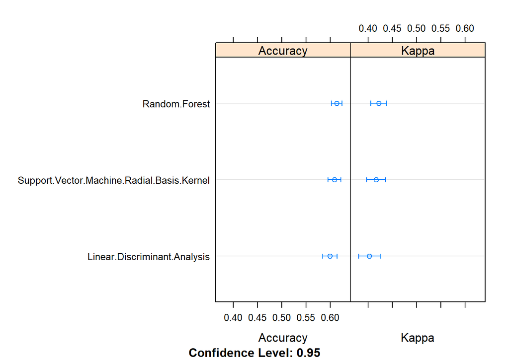

```r
dotplot(mc_results)
```

```r
print(rf_mod)
```

```
## Random Forest
##
## 450 samples
##   5 predictor
##   3 classes: 'Not.Readmission', 'Readmitted.in.30.days', 'Readmitted.in.last.14.days'
##
## No pre-processing
## Resampling: Bootstrapped (25 reps)
## Summary of sample sizes: 450, 450, 450, 450, 450, 450, ...
## Resampling results across tuning parameters:
##
##   mtry  Accuracy   Kappa
##   2     0.6135632  0.4216196
##   3     0.5888754  0.3837229
##   5     0.5729090  0.3595364
##
## Accuracy was used to select the optimal model using the largest value.
## The final value used for the model was mtry = 2.
```

The accuracy will start to decrease with multiple classification models. For these types of classifications - Deep Neural Networks might be a better option, plus it saves time on exploring features in the models - as these are what I call feature agnostic, as the model finds the relationships.

## Predict model fits on validation set

```r
set.seed(123)
mc_pred <- predict(rf_mod, newdata = validation)
head(mc_pred, 10)
```

```
##  [1] Readmitted.in.30.days      Readmitted.in.30.days
##  [3] Readmitted.in.30.days      Readmitted.in.30.days
##  [5] Readmitted.in.30.days      Readmitted.in.30.days
##  [7] Readmitted.in.last.14.days Readmitted.in.30.days
##  [9] Readmitted.in.30.days      Readmitted.in.30.days
## Levels: Not.Readmission Readmitted.in.30.days Readmitted.in.last.14.days
```

## Create confusion matrix to evaluate models against validation set

Now, the last step is to observe the confusion matrix fit for this:

```r
cm <- caret::confusionMatrix(mc_pred, validation$Outcome)
print(cm)
```

```
## Confusion Matrix and Statistics
##
##                             Reference
## Prediction                   Not.Readmission Readmitted.in.30.days
##   Not.Readmission                         30                     4
##   Readmitted.in.30.days                    0                    25
##   Readmitted.in.last.14.days               0                     1
##                             Reference
## Prediction                   Readmitted.in.last.14.days
##   Not.Readmission                                     3
##   Readmitted.in.30.days                               1
##   Readmitted.in.last.14.days                         26
##
## Overall Statistics
##
##                Accuracy : 0.9
##                  95% CI : (0.8186, 0.9532)
##     No Information Rate : 0.3333
##     P-Value [Acc > NIR] : <2e-16
##
##                   Kappa : 0.85
##
##  Mcnemar's Test P-Value : 0.0719
##
## Statistics by Class:
##
##                      Class: Not.Readmission Class: Readmitted.in.30.days
## Sensitivity                          1.0000                       0.8333
## Specificity                          0.8833                       0.9833
## Pos Pred Value                       0.8108                       0.9615
## Neg Pred Value                       1.0000                       0.9219
## Prevalence                           0.3333                       0.3333
## Detection Rate                       0.3333                       0.2778
## Detection Prevalence                 0.4111                       0.2889
## Balanced Accuracy                    0.9417                       0.9083
##                      Class: Readmitted.in.last.14.days
## Sensitivity                                     0.8667
## Specificity                                     0.9833
## Pos Pred Value                                  0.9630
## Neg Pred Value                                  0.9365
## Prevalence                                      0.3333
## Detection Rate                                  0.2889
## Detection Prevalence                            0.3000
## Balanced Accuracy                               0.9250
```

The confusion matrix metrics can then be evaluated to see how well the model performs at predicting associated confusion matrix measures, such as sensitivity (https://classeval.wordpress.com/introduction/basic-evaluation-measures/#:~:text=Sensitivity%20(Recall%20or%20True%20positive,whereas%20the%20worst%20is%200.0.) as well as other associated measures.